# R Notebook

```r
library(readxl)
```

Zadanie 1

```r
set.seed(120)
```

```r
nums <- rnorm(n = 100, mean = 6, sd = 2)
nums[1 : 5]
```

```
[1] 4.014986 9.351394 5.117674 4.553868 3.527454
```

```r
qqnorm(nums, col = "blue", xlab = "Kwantyle teoretyczne", ylab = "Kwantyle empiryczne", main='Wykres kwantyl-kwantyl')
qqline(nums, col = "red", lty = 2)
```

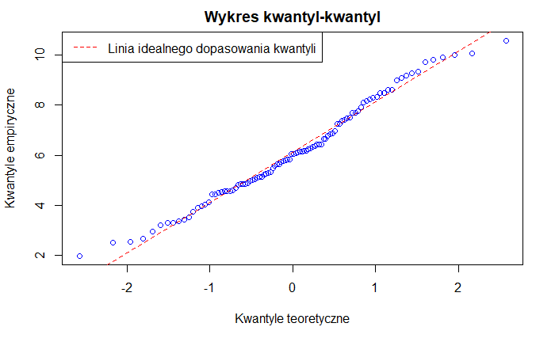

```r
legend("topleft", legend = "Linia idealnego dopasowania kwantyli", col = "red", lty = 2)
```

```r
shapiro.test(nums)
```

```
    Shapiro-Wilk normality test

data:  nums
W = 0.98279, p-value = 0.2179
```

Brak podstaw do odrzucenia hipotezy, że rozkład danych jest normalny.

Zadanie 2

```r
qchisq(.99, df=6)
```

```
[1] 16.81189
```

Zadanie 3

5. Exercise 6.4-14 W celu poprawy opieki prenatalnej nad matką i dzieckiem przeprowadzono badanie mające na celu stwierdzenie, czy liczba odwiedzin pielęgniarskich wpływa na masę urodzeniową noworodka. W tym celu ważono noworodki, których mamy zostały odwiedzone przez pielęgniarki pięć lub mniej razy w okresie ciąży oraz noworodki, których mamy były odwiedzane częściej. Czy intensywność opieki pielęgniarskiej wpływa na masę urodzeniową dziecka?

```r
data <- read_excel('exercise_6_4_14_Hogg_Tanis.xls')
head(data, 5)
```

| Pięć_lub_mniej | Więcej_niż_pięć |
| --- | --- |
| 49 | 133 |
| 108 | 108 |
| 110 | 93 |
| 82 | 119 |
| 93 | 119 |

```r
print(data[['Pięć_lub_mniej']] * 28.35)
```

```
 [1] 1389.15 3061.80 3118.50 2324.70 2636.55 3231.90
 [7] 3798.90 3231.90 2721.60 1474.20 2863.35 3231.90
[13] 3402.00 3288.60
```

Masy noworodków podano w uncjach.

```r
str(data)
```

```
Classes ‘tbl_df’, ‘tbl’ and 'data.frame':   14 obs. of  2 variables:
 $ Pięć_lub_mniej : num  49 108 110 82 93 114 134 114 96 52 ...
 $ Więcej_niż_pięć: num  133 108 93 119 119 98 106 87 153 116 ...
```

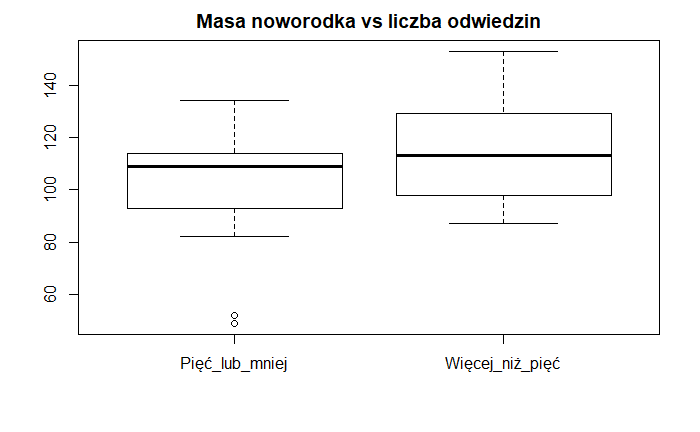

```r
boxplot(data, main = "Masa noworodka vs liczba odwiedzin", ylabel = 'Masa noworodka - uncje')
```

Widzimy, że w grupie poniżej 5 odwiedzin dwoje noworodków ważyli dosyć mało, ale rząd wielkości nie budzi podejrzeń co do poprawności danych.

```r
var(data[['Pięć_lub_mniej']])
```

```
[1] 604.489
```

```r
var(data[['Więcej_niż_pięć']])
```

```
[1] 329.2582
```

Wariancje w grupach nie są równe.

```r
# Adjusting the plotting area to display two plots side by side
par(mfrow = c(1, 2))

# Histogram of the first variable
hist(data[['Pięć_lub_mniej']], col = "red", main = "Rozkład masy noworodków dla mniejszej liczby odwiedzin", xlab = "Masa - uncje", ylab = "Liczność")

# Histogram of the second variable
hist(data[['Więcej_niż_pięć']], col = "blue", main = "Rozkład masy noworodków dla większej liczby odwiedzin", xlab = "Masa - uncje", ylab = "Liczność")

# Resetting the plotting area to default
par(mfrow = c(1, 1))
```

[output not shown]

```r
shapiro.test(data[['Pięć_lub_mniej']])
```

```
    Shapiro-Wilk normality test

data:  data[["Pięć_lub_mniej"]]
W = 0.86759, p-value = 0.03882
```

Przy poziomie istotności 0.05 uznajemy, że masa noworodków przy liczbie odwiedzin 0-5 nie ma rozkładu normalnego.

```r
shapiro.test(data[['Więcej_niż_pięć']])
```

```
    Shapiro-Wilk normality test

data:  data[["Więcej_niż_pięć"]]
W = 0.96986, p-value = 0.8747
```

Ponieważ rozkład w grupie poniżej 5 odwiedzin nie jest normalny, a wariancje w porównywanych grupach nie są równe, użyjemy testu Wilcoxon zamiast testu T.

```r
wilcox.test(data[['Pięć_lub_mniej']], data[['Więcej_niż_pięć']])
```

[output not shown]

```
    Wilcoxon rank sum test with continuity correction

data:  data[["Pięć_lub_mniej"]] and data[["Więcej_niż_pięć"]]
W = 71, p-value = 0.2228
alternative hypothesis: true location shift is not equal to 0
```

Brak podstaw do odrzucenia hipotezy, że obydwie grupy noworodków mają tę samą medianową masę. Test jest słaby i mamy mało obserwacji. Warto by powtórzyć test dla większej ilości obserwacji.

Zadanie 4

```r
pt(1, df = 8) - pt(-0.5, df = 8)
```

[output not shown]

Zadanie 5

```r
data1 <- rf(20, df1 = 4, df2 = 3)
data2 <- rf(20, df1 = 4, df2 = 3)

ks.test(data1, data2)
```

[output not shown]

Brak podstaw do odrzucenia hipotezy, że rozkłady mają te same dystrybuanty, a więc możemy nadal myśleć, że mają ten sam rozkład, co zgadza się ze stanem faktycznym.

Zadanie 6

```r
unif.nums <- runif(30, min = -40, max = 40)
boxplot(unif.nums, main = "Kwantylowy rozkład losowych liczb", ylab = "Wielkość liczby")
```

[output not shown]

Na podstawie wielkości liczb nie podejrzewamy występowania obserwacji odstających.

Zadanie 7

```r
zwierzeta <- data.frame(
  Nazwa = c("Muflon", "Lama", "Owca", "Koza", "Daniel"),
  Liczba = c(6, 4, 13, 16, 4)
)

barplot(zwierzeta$Liczba, names.arg = zwierzeta$Nazwa,
        col = "blue", main = "Liczba zwierząt w zoo wg rodzaju zwierzęcia",
        xlab = "Rodzaj zwierzęcia", ylab = "Liczba zwierząt")
```

[output not shown]